# **Finding Lane Lines on the Road**

**Advanced Lane Finding Project**

The goals / steps of this project are the following:

- Compute the camera calibration matrix and distortion coefficients given a set of chessboard images.
- Apply a distortion correction to raw images.
- Use color transforms, gradients, etc., to create a thresholded binary image.
- Apply a perspective transform to rectify binary image ("birds-eye view").
- Detect lane pixels and fit to find the lane boundary.
- Determine the curvature of the lane and vehicle position with respect to center.
- Warp the detected lane boundaries back onto the original image.
- Output visual display of the lane boundaries and numerical estimation of lane curvature and vehicle position.

## 1. Briefly state how you computed the camera matrix and distortion coefficients. Provide an example of a distortion corrected calibration image.

The first step in this project is to calibrate the camera using images of checkerboards, finding the corners and undistorting the camera to correct for bends in lines due to a camera's lens.

```python
#importing some useful packages
import matplotlib.pyplot as plt
import matplotlib.image as mpimg
import numpy as np
import cv2
%matplotlib inline

import glob
```

```
This image is: <class 'numpy.ndarray'> with dimesions: (720, 1280, 3)
```

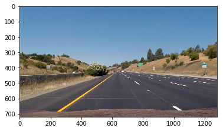

```python
#reading in an image
image = mpimg.imread('test_images/straight_lines1.jpg')
#printing out some stats and plotting
print('This image is:', type(image), 'with dimensions:', image.shape)
plt.imshow(image[520:580,:])  # if you wanted to show a single color channel image called 'gray', for example, call as plt.imshow(gray, cmap='gray')
img2=np.copy(image)
img2lines = cv2.line(img2[300:,150:850],(24,99),(92,500),255)
plt.imshow(image)

#cv2.line(img2[300:,150:850],(24,99),(92,500))
#img2lines = cv2.line(img2[300:,150:850],(24,99),(92,500),255)
```

[figure not shown]

```python
# Using a checkerboard image to perform undistort functions
# Read in an image
img = cv2.imread('/camera_cal/calibration1.jpg')
import glob

images = glob.glob('./camera_cal/calibration*.jpg')
nx = 9 # the number of inside corners in x
ny = 6 # the number of inside corners in y
objpoints = [] # 3D points in real world space
imgpoints= []  # 2D points in image plane
objp = np.zeros((ny*nx,3),np.float32)
objp[:,:2] = np.mgrid[0:nx,0:ny].T.reshape(-1,2) # x and y coordinates

#look at distorted calibration image and detect corners of board using findChessboard Corners
#plt1 = plt.figure(figsize=(41,41))
#i=0
for fname in images:
    img = mpimg.imread(fname)
    gray = cv2.cvtColor(img,cv2.COLOR_BGR2GRAY)
    ret, corners = cv2.findChessboardCorners(gray, (nx, ny), None)
    if ret==True:
        imgpoints.append(corners)
        objpoints.append(objp)
        img=cv2.drawChessboardCorners(img, (nx, ny), corners, ret)
        #plt.imshow(img)
        legends = plt1.add_subplot(10,5,i+1)
        #legends.imshow(img)
        ret, mtx, dist, rvecs, tvecs = cv2.calibrateCamera(objpoints, imgpoints, gray.shape[::-1], None, None)
        undist = cv2.undistort(img, mtx, dist, None, mtx)
        legends = plt1.add_subplot(10,5,i+1)
        #legends.imshow(undist)
#plt1.show()
#ret, mtx, dist, rvecs, tvecs = cv2.calibrateCamera(objpoints, imgpoints, gray.shape[::-1], None, None)

#undist = cv2.undistort(img, mtx, dist, None, mtx)
```

### Answer:

I first load all of the images with checkerboards.In each image, I capture the xyz coordinates of the checkerboard corners as object points. Using these, I create a list called objpoints, which is the replicated coordinates for corners detected with all images. I detect the corners using cv2.findChessboardCorners(). Using these, when corners are successfully found, I make imgpoints, which are the xy coordinates for corners in an image plane, rather than a real world picture with z coordinates. Using these 2 lists, the camera can be calibrated using cv2,CalibrateCamera()

After the camera is calibrated, we can then use cv2.undistort() to get the result below.

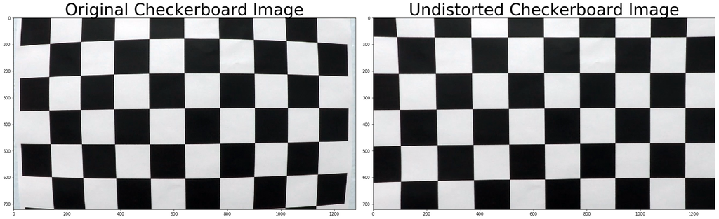

```python
#plt.imshow(img)
img = cv2.imread('./camera_cal/calibration1.jpg')
undist = cv2.undistort(img, mtx, dist, None, mtx)
f, (ax1, ax2) = plt.subplots(1, 2, figsize=(24, 9))
f.tight_layout()
ax1.imshow(img)
ax1.set_title('Original Checkerboard Image', fontsize=40)
ax2.imshow(undist)
ax2.set_title('Undistorted Checkerboard Image', fontsize=40)
plt.subplots_adjust(left=0., right=1, top=0.9, bottom=0.)
```

## 2. Describe how (and identify where in your code) you used color transforms, gradients or other methods to create a thresholded binary image. Provide an example of a binary image result.

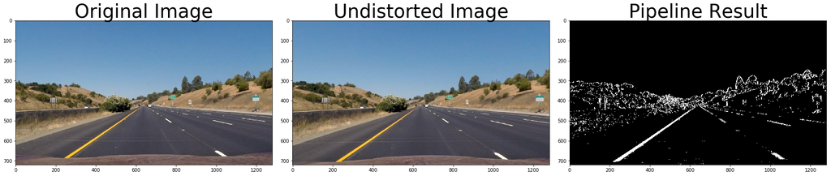

```python
# Image Processing pipeline

# Edit this function to create your own pipeline.
def pipeline(img, s_thresh=(170, 255), sx_thresh=(20, 100)):
    img = np.copy(img)
    # Convert to HSV color space and separate the V channel
    hsv = cv2.cvtColor(img, cv2.COLOR_RGB2HLS).astype(np.float)
    l_channel = hsv[:,:,1]
    s_channel = hsv[:,:,2]
    # Sobel x
    sobelx = cv2.Sobel(l_channel, cv2.CV_64F, 1, 0) # Take the derivative in x
    abs_sobelx = np.absolute(sobelx) # Absolute x derivative to accentuate lines away from horizontal
    scaled_sobel = np.uint8(255*abs_sobelx/np.max(abs_sobelx))

    # Threshold x gradient
    sxbinary = np.zeros_like(scaled_sobel)
    sxbinary[(scaled_sobel >= sx_thresh[0]) & (scaled_sobel <= sx_thresh[1])] = 1

    # Threshold color channel
    s_binary = np.zeros_like(s_channel)
    s_binary[(s_channel >= s_thresh[0]) & (s_channel <= s_thresh[1])] = 1

    #Threshold light values
    l_binary = np.zeros_like(l_channel)
    l_binary[(l_channel >= 60) & (l_channel <= 255)] = 1


    # Stack each channel
    # Note color_binary[:, :, 0] is all 0s, effectively an all black image. It might
    # be beneficial to replace this channel with something else.
    #color_binary = np.dstack(( l_binary, sxbinary, s_binary))
    color_binary = np.zeros_like(sxbinary)
    color_binary[((l_binary == 1) & (s_binary == 1) | (sxbinary==1))] = 1
    color_binary = 255*np.dstack((color_binary,color_binary,color_binary)).astype('uint8')
    return color_binary

img3 = mpimg.imread('test_images/straight_lines1.jpg')
undist3 = cv2.undistort(img3, mtx, dist, None, mtx)
result = pipeline(undist3)

# Plot the result
f, (ax1, ax2, ax3) = plt.subplots(1, 3, figsize=(24, 9))
f.tight_layout()

ax1.imshow(img3)
ax1.set_title('Original Image', fontsize=40)
ax2.imshow(undist3)
ax2.set_title('Undistorted Image', fontsize=40)
ax3.imshow(result)
ax3.set_title('Pipeline Result', fontsize=40)
plt.subplots_adjust(left=0., right=1, top=0.9, bottom=0.)
```

## 3. Describe how (and identify where in your code) you performed a perspective transform and provide an example of a transformed image.

```
365
365 1045 640
```

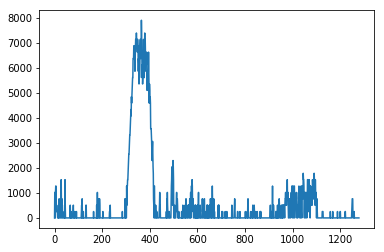

```python
import numpy as np
#Plotting a histogram from the bottom of the image:
histogram = np.sum(result[result.shape[0]-100:,:], axis=0)
#plt.plot(histogram)
midpoint = np.int(histogram.shape[0]/2)
leftx_base = np.argmax(histogram[:midpoint,1])
rightx_base = np.argmax(histogram[midpoint:,1])+midpoint
#plt.plot(histogram[:midpoint,:2])
plt.plot(histogram[:,1])
print()
print(np.argmax(histogram[:midpoint,0]))
print(leftx_base,rightx_base,midpoint)
```

### Answer 3 Part A

I first use a method to get a histogram bottom slice of the x values and very bottom of the y values of the undistorted and processed image. The max of these values indicate where the lines for a picture are first starting.

```
74
25
```

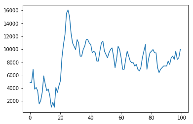

```python
import numpy as np
#Plotting a histogram from the bottom of the image:
histogramy = np.sum(result[result.shape[0]-100:,:], axis=1)
#plt.plot(histogram)
ybase = np.argmax(histogramy[::-1,1])
plt.plot(histogramy[::-1,1])
print()
print(np.argmax(histogramy[:midpoint,0]))
print(ybase)
```

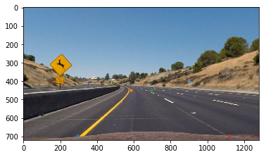

```python
#undist3 = cv2.undistort(img3, mtx, dist, None, mtx)
plt.imshow(undist3)
upperxoffset = 55
lowerxoffset= 70
imy=undist3.shape[0]
roi1 = (leftx_base-lowerxoffset, imy-ybase )
roi2 = (midpoint-upperxoffset, imy-270 )
roi3 = (midpoint +upperxoffset, imy-270 )
roi4 = (rightx_base+lowerxoffset, imy-ybase )

plt.plot(roi1[0],roi1[1] ,'.' )
plt.plot(roi2[0],roi2[1] ,'.' )
plt.plot(roi3[0],roi3[1] ,'.' )
plt.plot(roi4[0],roi4[1] ,'.' )
```

### Answer 3 Part B

I use these to determine where the road's lane lines rectangle shows up as seen in the points above:

```python
src = np.float32((roi1,roi2,roi3,roi4))
print(src)
warp_offsetx=550
warp_offsety=200
destroi1=(midpoint-warp_offsetx,imy)
destroi2=(midpoint-warp_offsetx,imy-4*warp_offsety)
destroi3=(midpoint+warp_offsetx,imy-4*warp_offsety)
destroi4=(midpoint+warp_offsetx,imy)
dst = np.float32((destroi1,destroi2,destroi3,destroi4))
print(dst)
```

```
[[  295.   695.]
 [  585.   450.]
 [  695.   450.]
 [ 1115.   695.]]
[[   90.   720.]
 [   90.   -80.]
 [ 1190.   -80.]
 [ 1190.   720.]]
```

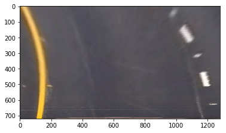

```python
# Using the pixels to warp perspective on the image:

#Compute the perspective transform, M, given source and destination points:
img_size = (undist3.shape[1],undist3.shape[0])
M = cv2.getPerspectiveTransform(src, dst)

#Compute the inverse perspective transform:

Minv = cv2.getPerspectiveTransform(dst, src)

#Warp an image using the perspective transform, M:

warped = cv2.warpPerspective(undist3, M, img_size, flags=cv2.INTER_LINEAR)
binary_warped = cv2.warpPerspective(result, M, img_size, flags=cv2.INTER_LINEAR)
plt.imshow(warped)
```

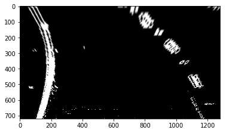

```python
plt.imshow(binary_warped)
```

### Answer 3 Part C

I draw another rectangle to where the polygon we previously drew will be redrawn: I use a list of the vertices in corresponding order from the source as src to the destination as dst. Using cv2.getPerspectiveTransform(src, dst), I get a matrix for M that will be used in cv2.warpPerspective to get a warped image. I also prepare an Minv so after detecting lane lines, I can reverse this warp.

## 4. Describe how (and identify where in your code) you identified lane-line pixels and fit their positions with a polynomial?

```
(720, 1280, 3)
```

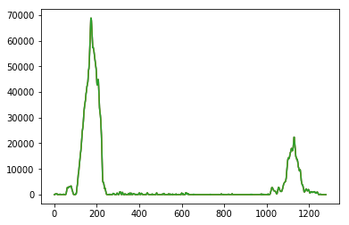

```python
hist_offset=70
#histogram_lines = np.sum(warped2[warped2.shape[0]/2:,midpoint-hist_offset:midpoint+hist_offset], axis=0)
histogram_lines = np.sum(binary_warped[binary_warped.shape[0]/2:,], axis=0)
plt.plot(histogram_lines)

print(binary_warped.shape)
```

### Answer 4 Part A:

I brute forced the entire pipeline by using sliding window searches. Other methods such as using previous location of the line and caching memory of last 5 frames caused my pipeline to draw lines on cars and other road structures, hence the brute force method.

First, I have the binary_warped image that shows the top down view of the lane. I turn into a histogram and collect the left and right lane line's x values.

Using these as a base, I search in 9 windows above this to track where a minimum of 50 pixels of lines are adjacent to the window below. This method draws out the windows searched for reference, and shows the tracking:

```python
# Take a histogram of the bottom half of the image


out_img = np.dstack((binary_warped[:,:,0], binary_warped[:,:,1], binary_warped[:,:,2]))*255

# Find the peak of the left and right halves of the histogram
# These will be the starting point for the left and right lines
midpoint = np.int(histogram_lines.shape[0]/2)
leftx_base = np.argmax(histogram_lines[:midpoint,2])-10
rightx_base = np.argmax(histogram_lines[midpoint:,2]) + midpoint


# Choose the number of sliding windows
nwindows = 9
# Set height of windows
window_height = np.int(binary_warped.shape[0]/nwindows)
# Identify the x and y positions of all nonzero pixels in the image
nonzero = binary_warped.nonzero()
nonzeroy = np.array(nonzero[0])
nonzerox = np.array(nonzero[1])
# Current positions to be updated for each window
leftx_current = leftx_base
rightx_current = rightx_base
# Set the width of the windows +/- margin
margin = 100
# Set minimum number of pixels found to recenter window
minpix = 50
# Create empty lists to receive left and right lane pixel indices
left_lane_inds = []
right_lane_inds = []

# Step through the windows one by one
for window in range(nwindows):
    # Identify window boundaries in x and y (and right and left)

    win_y_low = binary_warped.shape[0] - (window+1)*window_height
    win_y_high = binary_warped.shape[0] - window*window_height
    win_xleft_low = leftx_current - margin
    win_xleft_high = leftx_current + margin
    win_xright_low = rightx_current - margin
    win_xright_high = rightx_current + margin

    # Draw the windows on the visualization image
    cv2.rectangle(out_img,(win_xleft_low,win_y_low),(win_xleft_high,win_y_high),(0,255,0), 2)
    cv2.rectangle(out_img,(win_xright_low,win_y_low),(win_xright_high,win_y_high),(0,255,0), 2)
    #print(win_xleft_low,win_y_low,win_xleft_high,win_y_high)
    #print(win_xright_low,win_y_low,win_xright_high,win_y_high)
    # Identify the nonzero pixels in x and y within the window

    good_left_inds = ((nonzeroy >= win_y_low) & (nonzeroy < win_y_high) & (nonzerox >= win_xleft_low) & (nonzerox < win_xleft_high)).nonzero()[0]
    good_right_inds = ((nonzeroy >= win_y_low) & (nonzeroy < win_y_high) & (nonzerox >= win_xright_low) & (nonzerox < win_xright_high)).nonzero()[0]
    # Append these indices to the lists

    left_lane_inds.append(good_left_inds)
    right_lane_inds.append(good_right_inds)

    # If you found > minpix pixels, recenter next window on their mean position
    if len(good_left_inds) > minpix:
        leftx_current = np.int(np.mean(nonzerox[good_left_inds]))
    if len(good_right_inds) > minpix:
        rightx_current = np.int(np.mean(nonzerox[good_right_inds]))

# Concatenate the arrays of indices
left_lane_inds = np.concatenate(left_lane_inds)
right_lane_inds = np.concatenate(right_lane_inds)

# Extract left and right line pixel positions
leftx = nonzerox[left_lane_inds]
lefty = nonzeroy[left_lane_inds]
rightx = nonzerox[right_lane_inds]
righty = nonzeroy[right_lane_inds]

# Fit a second order polynomial to each
left_fit = np.polyfit(lefty, leftx, 2)
right_fit = np.polyfit(righty, rightx, 2)

#Visualization
```

[output not shown]

```
260 1006
```

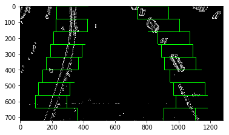

```python
#drawing on binary warped image of rectangles that lines were discovered:
plt.imshow(out_img)
#print(out_img.shape)
#plt.imshow(binary_warped[:,:,1])
print(leftx_base,rightx_base)
```

```
(720, 0)
```

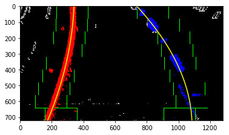

```python
# Generate x and y values for plotting
ploty = np.linspace(0, binary_warped.shape[0]-1, binary_warped.shape[0] )
left_fitx = left_fit[0]*ploty**2 + left_fit[1]*ploty + left_fit[2]
right_fitx = right_fit[0]*ploty**2 + right_fit[1]*ploty + right_fit[2]

out_img[nonzeroy[left_lane_inds], nonzerox[left_lane_inds]] = [255, 0, 0]
out_img[nonzeroy[right_lane_inds], nonzerox[right_lane_inds]] = [0, 0, 255]
plt.imshow(out_img)
plt.plot(left_fitx, ploty, color='yellow')
plt.plot(right_fitx, ploty, color='yellow')
plt.xlim(0, 1280)
plt.ylim(720, 0)
```

### Answer 4 Part B:

I used an index of left lane line pixes and right lane line pixels as they were captured in order. With these nonzero lane line pixel values, I used np.polyfit to fit a second degree polygon to find a curving left and right lane lines above.

## 5. Describe how (and identify where in your code) you calculated the radius of curvature of the lane and the position of the vehicle with respect to center.

```python
y_eval = np.max(ploty)
left_curverad = ((1 + (2*left_fit[0]*y_eval + left_fit[1])**2)**1.5) / np.absolute(2*left_fit[0])
right_curverad = ((1 + (2*right_fit[0]*y_eval + right_fit[1])**2)**1.5) / np.absolute(2*right_fit[0])
print(left_curverad, right_curverad,ploty.shape)
```

```
2460.66961715 827.114755022 (720,)
```

```python
# Define conversions in x and y from pixels space to meters
ym_per_pix = 30/720 # meters per pixel in y dimension
xm_per_pix = 3.7/1280 # meters per pixel in x dimension

# Fit new polynomials to x,y in world space
left_fit_cr = np.polyfit(ploty*ym_per_pix, left_fitx*xm_per_pix, 2)
right_fit_cr = np.polyfit(ploty*ym_per_pix, right_fitx*xm_per_pix, 2)
# Calculate the new radii of curvature
left_curverad = ((1 + (2*left_fit_cr[0]*y_eval*ym_per_pix + left_fit_cr[1])**2)**1.5) / np.absolute(2*left_fit_cr[0])
right_curverad = ((1 + (2*right_fit_cr[0]*y_eval*ym_per_pix + right_fit_cr[1])**2)**1.5) / np.absolute(2*right_fit_cr[0])
# Now our radius of curvature is in meters
print(left_curverad, 'm', right_curverad, 'm')
# Example values: 632.1 m    626.2 m
```

```
1164.11742894 m 495.194674379 m
```

### Answer 5:

I implemented this by using the equation for collecting the radius of curvature for a polynomial curve. if f'y = 2Ay + B if f"y = 2A the Radius is R = 1/2A * (1+(2Ay+B)^2 )^3/2

I changed the scalar for the meters per pixels in y and x direction to match the pixel ranges in the input images: 720 for y, 1280 for x, and used the following code to perform this equation:

left_curverad = ((1 + (2*left_fit_cr[0]*y_eval*ym_per_pix + left_fit_cr[1])**2)**1.5) / np.absolute(2*left_fit_cr[0]) right_curverad = ((1 + (2*right_fit_cr[0]*y_eval*ym_per_pix + right_fit_cr[1])**2)**1.5) / np.absolute(2*right_fit_cr[0])

For the above road, the left line radius was 1164 meters, and the right line radius was 495 meters.

## 6. Provide an example image of your result plotted back down onto the road such that the lane area is identified clearly.

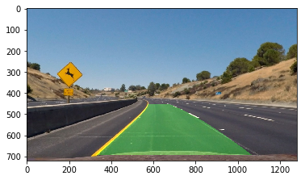

```python
# creating a new image with the lines drawn:

# Create an image to draw the lines on
warp_zero = np.zeros_like(binary_warped).astype(np.uint8)
color_warp = np.dstack((warp_zero[:,:,0], warp_zero[:,:,1], warp_zero[:,:,2]))

# Recast the x and y points into usable format for cv2.fillPoly()
pts_left = np.array([np.transpose(np.vstack([left_fitx, ploty]))])
pts_right = np.array([np.flipud(np.transpose(np.vstack([right_fitx, ploty])))])
pts = np.hstack((pts_left, pts_right))

# Draw the lane onto the warped blank image
cv2.fillPoly(color_warp, np.int_([pts]), (0,255, 0))

# Warp the blank back to original image space using inverse perspective matrix (Minv)
newwarp = cv2.warpPerspective(color_warp, Minv, (image.shape[1], image.shape[0]))
# Combine the result with the original image
result = cv2.addWeighted(undist3, 1, newwarp, 0.3, 0)
plt.imshow(result)
```

### Answer 6:

Please find the above image that shows the result of the processes discussed above:

## 1. Provide a link to your final video output. Your pipeline should perform reasonably well on the entire project video (wobbly lines are ok but no catastrophic failures that would cause the car to drive off the road!).

## Answer:

I used a separate notebook named Video_Pipeline that packages all of the logic above and creates a new video with lane lines drawn. I used the first projects video processing code to do the same with this new logic.

Please find it in this repo also the video: project_video_processed.mp4

# Discussion:

## 1. Briefly discuss any problems / issues you faced in your implementation of this project. Where will your pipeline likely fail? What could you do to make it more robust?

I had problems when I tried to chase the line line further up the road. I noticed other artifacts like shadows and road dividers and other cars would be detected by my histogram pixel detection strategy. This is why I restricted my warped window to only include the lines, this doesnt give the best range of lines. Here is an example below:

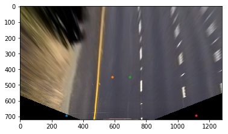

```python
upperxoffset = 55
lowerxoffset= 70
imy=undist3.shape[0]
roi1 = (leftx_base-lowerxoffset, imy-ybase )
roi2 = (midpoint-upperxoffset, imy-270 )
roi3 = (midpoint +upperxoffset, imy-270 )
roi4 = (rightx_base+lowerxoffset, imy-ybase )

plt.plot(roi1[0],roi1[1] ,'.' )
plt.plot(roi2[0],roi2[1] ,'.' )
plt.plot(roi3[0],roi3[1] ,'.' )
plt.plot(roi4[0],roi4[1] ,'.' )

src = np.float32((roi1,roi2,roi3,roi4))
warp_offsetx=150
warp_offsety=150
destroi1=(midpoint-warp_offsetx,imy)
destroi2=(midpoint-warp_offsetx,imy-4*warp_offsety)
destroi3=(midpoint+warp_offsetx,imy-4*warp_offsety)
destroi4=(midpoint+warp_offsetx,imy)
dst = np.float32((destroi1,destroi2,destroi3,destroi4))

#Compute the perspective transform, M, given source and destination points:
img_size = (undist3.shape[1],undist3.shape[0])
M = cv2.getPerspectiveTransform(src, dst)

#Compute the inverse perspective transform:

Minv = cv2.getPerspectiveTransform(dst, src)

#Warp an image using the perspective transform, M:

warped = cv2.warpPerspective(undist3, M, img_size, flags=cv2.INTER_LINEAR)
binary_warped = cv2.warpPerspective(result, M, img_size, flags=cv2.INTER_LINEAR)
plt.imshow(warped)
```

## Discussion Continued:

when this occured, other parts of the road such as the divider on the left and other cars then started getting picked up as lane lines.

The tradeoff is more accurate lane detection and the drawback was I couldnt get the very top part of the road to be part of the lane detection. I also faced issues implementing a lane detection strategy that doesn't use the sliding window. This, though processing takes time, was the most accurate method I had. I used a mechanism to search for nearby lines from the previous image frame, which worked fast and efficiently, but sometimes this found a car and projected a lane path ontop of this. to minimize risk of accidentally driving into that car, I just used sliding window. I plan to experiment with the lines() class, and see how to make a robust and advanced lane detection pipeline. Any tips and pseudocode would be much appreciated!

## Test on Videos

You know what's cooler than drawing lanes over images? Drawing lanes over video!

We can test our solution on two provided videos:

`solidWhiteRight.mp4`

`solidYellowLeft.mp4`

**Note: if you get an `import error` when you run the next cell, try changing your kernel (select the Kernel menu above --> Change Kernel). Still have problems? Try relaunching Jupyter Notebook from the terminal prompt. Also, check out [this forum post](https://carnd-forums.udacity.com/questions/22677062/answers/22677109) for more troubleshooting tips.**

**If you get an error that looks like this:**

```
NeedDownloadError: Need ffmpeg exe.
You can download it by calling:
imageio.plugins.ffmpeg.download()
```

**Follow the instructions in the error message and check out [this forum post](https://carnd-forums.udacity.com/display/CAR/questions/26218840/import-videofileclip-error) for more troubleshooting tips across operating systems.**

```python
# Import everything needed to edit/save/watch video clips
from moviepy.editor import VideoFileClip
from IPython.display import HTML
```

```python
white_output = 'white.mp4'
clip1 = VideoFileClip("solidWhiteRight.mp4")
white_clip = clip1.fl_image(process_image) #NOTE: this function expects color images!!
%time white_clip.write_videofile(white_output, audio=False)
```

```
[MoviePy] >>>> Building video white.mp4
[MoviePy] Writing video white.mp4
```

```
[MoviePy] Done.
[MoviePy] >>>> Video ready: white.mp4

Wall time: 12.9 s
```

Play the video inline, or if you prefer find the video in your filesystem (should be in the same directory) and play it in your video player of choice.

```python
HTML("""
<video width="960" height="540" controls>
  <source src="{0}">
</video>
""".format(white_output))
```

[video not shown]

**At this point, if you were successful you probably have the Hough line segments drawn onto the road, but what about identifying the full extent of the lane and marking it clearly as in the example video (P1_example.mp4)? Think about defining a line to run the full length of the visible lane based on the line segments you identified with the Hough Transform. Modify your draw_lines function accordingly and try re-running your pipeline.**

```python
import math

def grayscale(img):
    """Applies the Grayscale transform
    This will return an image with only one color channel
    but NOTE: to see the returned image as grayscale
    (assuming your grayscaled image is called 'gray')
    you should call plt.imshow(gray, cmap='gray')"""
    return cv2.cvtColor(img, cv2.COLOR_RGB2GRAY)
    # Or use BGR2GRAY if you read an image with cv2.imread()
    # return cv2.cvtColor(img, cv2.COLOR_BGR2GRAY)

def canny(img, low_threshold, high_threshold):
    """Applies the Canny transform"""
    return cv2.Canny(img, low_threshold, high_threshold)

def gaussian_blur(img, kernel_size):
    """Applies a Gaussian Noise kernel"""
    return cv2.GaussianBlur(img, (kernel_size, kernel_size), 0)

def region_of_interest(img, vertices):
    """
    Applies an image mask.

    Only keeps the region of the image defined by the polygon
    formed from `vertices`. The rest of the image is set to black.
    """
    #defining a blank mask to start with
    mask = np.zeros_like(img)

    #defining a 3 channel or 1 channel color to fill the mask with depending on the input image
    if len(img.shape) > 2:
        channel_count = img.shape[2]  # i.e. 3 or 4 depending on your image
        ignore_mask_color = (255,) * channel_count
    else:
        ignore_mask_color = 255

    #filling pixels inside the polygon defined by "vertices" with the fill color
    cv2.fillPoly(mask, vertices, ignore_mask_color)

    #returning the image only where mask pixels are nonzero
    masked_image = cv2.bitwise_and(img, mask)
    return masked_image


def draw_lines(img, lines, color=[255, 0, 0], thickness=10):
    """
    NOTE: this is the function you might want to use as a starting point once you want to
    average/extrapolate the line segments you detect to map out the full
    extent of the lane (going from the result shown in raw-lines-example.mp4
    to that shown in P1_example.mp4).

    Think about things like separating line segments by their
    slope ((y2-y1)/(x2-x1)) to decide which segments are part of the left
    line vs. the right line.  Then, you can average the position of each of
    the lines and extrapolate to the top and bottom of the lane.

    This function draws `lines` with `color` and `thickness`.
    Lines are drawn on the image inplace (mutates the image).
    If you want to make the lines semi-transparent, think about combining
    this function with the weighted_img() function below
    """

    Rslope = []
    Lslope = []

    Llines = []
    Rlines = []

    for line in lines:
        for x1, y1, x2, y2 in line:
            m = ((y2-y1)/(x2-x1)) # slope
            if m < 0:
                Lslope.append(m)
                Llines.append((x2,y2))
            else:
                Rslope.append(m)
                Rlines.append((x1,y1))

    Rslope = sorted(Rslope)[int(len(Rslope)/2)]
    Lslope = sorted(Lslope)[int(len(Lslope)/2)]

    yleft = min([line[1] for line in Llines])
    left_combined = tuple([line[0] for line in Llines if line[1] == yleft] + [yleft])

    Rleft = min([line[1] for line in Rlines])
    right_combined = tuple([line[0] for line in Rlines if line[1] == Rleft] + [Rleft])

    xleft = int((img.shape[1]-left_combined[1])/Lslope) + left_combined[0]
    xright = int((img.shape[1]-right_combined[1])/Rslope) + right_combined[0]

    cv2.line(img, left_combined, (xleft, img.shape[1]), color, thickness)
    cv2.line(img, right_combined, (xright, img.shape[1]), color, thickness)


def hough_lines(img, rho, theta, threshold, min_line_len, max_line_gap):
    """
    `img` should be the output of a Canny transform.

    Returns an image with hough lines drawn.
    """
    lines = cv2.HoughLinesP(img, rho, theta, threshold, np.array([]), minLineLength=min_line_len, maxLineGap=max_line_gap)
    line_img = np.zeros((img.shape[0], img.shape[1], 3), dtype=np.uint8)
    draw_lines(line_img, lines)
    return line_img

# Python 3 has support for cool math symbols.

def weighted_img(img, initial_img, α=0.8, β=1., λ=0.):
    """
    `img` is the output of the hough_lines(), An image with lines drawn on it.
    Should be a blank image (all black) with lines drawn on it.

    `initial_img` should be the image before any processing.

    The result image is computed as follows:

    initial_img * α + img * β + λ
    NOTE: initial_img and img must be the same shape!
    """
    return cv2.addWeighted(initial_img, α, img, β, λ)
```